# Data 621 Homework 3

Sung Lee

10/21/2021

# Introduction

In this homework assignment, you will explore, analyze and model a data set containing information on crime for various neighborhoods of a major city. Each record has a response variable indicating whether or not the crime rate is above the median crime rate (1) or not (0).

Your objective is to build a binary logistic regression model on the training data set to predict whether the neighborhood will be at risk for high crime levels. You will provide classifications and probabilities for the evaluation data set using your binary logistic regression model. You can only use the variables given to you (or variables that you derive from the variables provided). Below is a short description of the variables of interest in the data set:

| Variable | Description |
| --- | --- |
| zn | proportion of residential land zoned for large lots (over 25000 square feet) (predictor variable) |
| indus | proportion of non-retail business acres per suburb (predictor variable) |
| chas | a dummy var. for whether the suburb borders the Charles River (1) or not (0) (predictor variable) |
| nox | nitrogen oxides concentration (parts per 10 million) (predictor variable) |
| rm | average number of rooms per dwelling (predictor variable) |
| age | proportion of owner-occupied units built prior to 1940 (predictor variable) |
| dis | weighted mean of distances to five Boston employment centers (predictor variable) |
| rad | index of accessibility to radial highways (predictor variable) |
| tax | full-value property-tax rate per $10,000 (predictor variable) |
| ptratio | pupil-teacher ratio by town (predictor variable) |
| lstat | lower status of the population (percent) (predictor variable) |
| medv | median value of owner-occupied homes in $1000s (predictor variable) |
| target | whether the crime rate is above the median crime rate (1) or not (0) (response variable) |

# Data Exploration

The following is a snippet of the training data along with summary and other statistics:

|  | zn | indus | chas | nox | rm | age | dis | rad | tax | ptratio | lstat | medv | target |
| --- | --- | --- | --- | --- | --- | --- | --- | --- | --- | --- | --- | --- | --- |
| 1 | 0 | 19.58 | 0 | 0.605 | 7.929 | 96.2 | 2.046 | 5 | 403 | 14.7 | 3.70 | 50.0 | 1 |
| 2 | 0 | 19.58 | 1 | 0.871 | 5.403 | 100.0 | 1.322 | 5 | 403 | 14.7 | 26.82 | 13.4 | 1 |
| 3 | 0 | 18.10 | 0 | 0.740 | 6.485 | 100.0 | 1.978 | 24 | 666 | 20.2 | 18.85 | 15.4 | 1 |
| 4 | 30 | 4.93 | 0 | 0.428 | 6.393 | 7.8 | 7.035 | 6 | 300 | 16.6 | 5.19 | 23.7 | 0 |
| 5 | 0 | 2.46 | 0 | 0.488 | 7.155 | 92.2 | 2.701 | 3 | 193 | 17.8 | 4.82 | 37.9 | 0 |
| 6 | 0 | 8.56 | 0 | 0.520 | 6.781 | 71.3 | 2.856 | 5 | 384 | 20.9 | 7.67 | 26.5 | 0 |

```
##        zn            indus            chas             nox
##  Min.   :  0.0   Min.   : 0.46   Min.   :0.0000   Min.   :0.389
##  1st Qu.:  0.0   1st Qu.: 5.14   1st Qu.:0.0000   1st Qu.:0.448
##  Median :  0.0   Median : 9.69   Median :0.0000   Median :0.538
##  Mean   : 11.6   Mean   :11.11   Mean   :0.0708   Mean   :0.554
##  3rd Qu.: 16.2   3rd Qu.:18.10   3rd Qu.:0.0000   3rd Qu.:0.624
##  Max.   :100.0   Max.   :27.74   Max.   :1.0000   Max.   :0.871
##        rm            age             dis             rad             tax
##  Min.   :3.86   Min.   :  2.9   Min.   : 1.13   Min.   : 1.00   Min.   :187
##  1st Qu.:5.89   1st Qu.: 43.9   1st Qu.: 2.10   1st Qu.: 4.00   1st Qu.:281
##  Median :6.21   Median : 77.2   Median : 3.19   Median : 5.00   Median :334
##  Mean   :6.29   Mean   : 68.4   Mean   : 3.80   Mean   : 9.53   Mean   :410
##  3rd Qu.:6.63   3rd Qu.: 94.1   3rd Qu.: 5.21   3rd Qu.:24.00   3rd Qu.:666
##  Max.   :8.78   Max.   :100.0   Max.   :12.13   Max.   :24.00   Max.   :711
##     ptratio         lstat            medv          target
##  Min.   :12.6   Min.   : 1.73   Min.   : 5.0   Min.   :0.000
##  1st Qu.:16.9   1st Qu.: 7.04   1st Qu.:17.0   1st Qu.:0.000
##  Median :18.9   Median :11.35   Median :21.2   Median :0.000
##  Mean   :18.4   Mean   :12.63   Mean   :22.6   Mean   :0.491
##  3rd Qu.:20.2   3rd Qu.:16.93   3rd Qu.:25.0   3rd Qu.:1.000
##  Max.   :22.0   Max.   :37.97   Max.   :50.0   Max.   :1.000
```

|  | zn | indus | chas | nox | rm | age | dis | rad | tax | ptratio | lstat | medv | target |
| --- | --- | --- | --- | --- | --- | --- | --- | --- | --- | --- | --- | --- | --- |
| median | 0.000 | 9.6900 | 0.00000 | 0.538000 | 6.21000 | 77.1500 | 3.1909 | 5.0000 | 334.500 | 18.9000 | 11.3500 | 21.2000 | 0.00000 |
| mean | 11.577 | 11.1050 | 0.07082 | 0.554311 | 6.29067 | 68.3676 | 3.7957 | 9.5300 | 409.502 | 18.3985 | 12.6315 | 22.5893 | 0.49142 |
| SE.mean | 1.082 | 0.3171 | 0.01190 | 0.005404 | 0.03265 | 1.3120 | 0.0976 | 0.4024 | 7.778 | 0.1018 | 0.3290 | 0.4280 | 0.02318 |
| CI.mean.0.95 | 2.127 | 0.6232 | 0.02338 | 0.010620 | 0.06416 | 2.5781 | 0.1918 | 0.7907 | 15.284 | 0.2000 | 0.6465 | 0.8411 | 0.04556 |
| var | 545.907 | 46.8657 | 0.06594 | 0.013611 | 0.49682 | 802.1005 | 4.4392 | 75.4453 | 28190.440 | 4.8261 | 50.4369 | 85.3717 | 0.25046 |
| std.dev | 23.365 | 6.8459 | 0.25679 | 0.116667 | 0.70485 | 28.3214 | 2.1069 | 8.6859 | 167.900 | 2.1968 | 7.1019 | 9.2397 | 0.50046 |
| coef.var | 2.018 | 0.6165 | 3.62621 | 0.210472 | 0.11205 | 0.4143 | 0.5551 | 0.9114 | 0.410 | 0.1194 | 0.5622 | 0.4090 | 1.01841 |

There are no missing values in the training data. As noted above, `target` is the dependent variable with 12 other variables with which we can decide to build the model.

## Distributions

The following are the distributions for the variables:

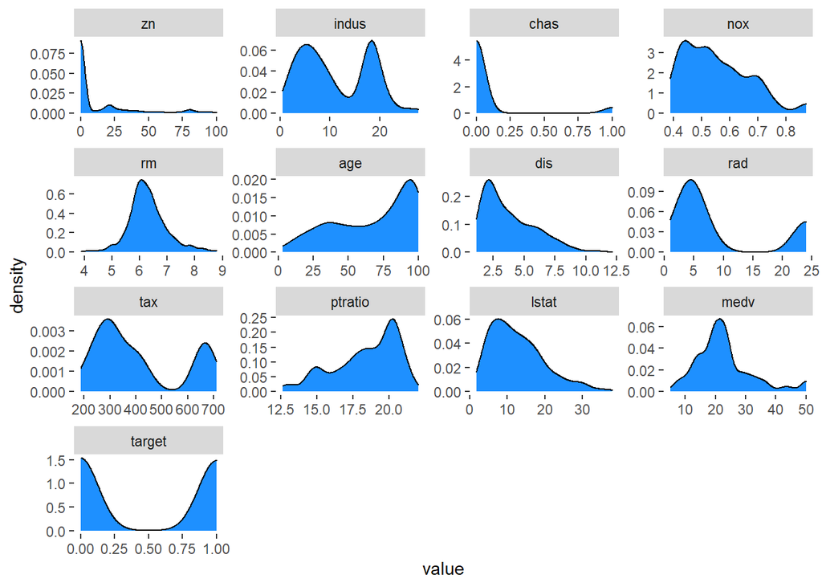

Here are some general observations:

The variable `zn` (proportion of residential land zoned for large lots) is small and a log transformation is needed. For the variable `chas` there is a skew of hourses not bounding the Charles River and probably not good as a predictor variable.

## Skewness

The following looks at the skewness of each of the variables:

```
##       zn    indus     chas      nox       rm      age      dis      rad
##  2.18384  0.28948  3.34626  0.74874  0.48087 -0.57957  1.00212  1.01354
##      tax  ptratio    lstat     medv   target
##  0.66144 -0.75670  0.90851  1.08017  0.03434
```

## Boxplots

The following is a plot of the boxplots for the variables:

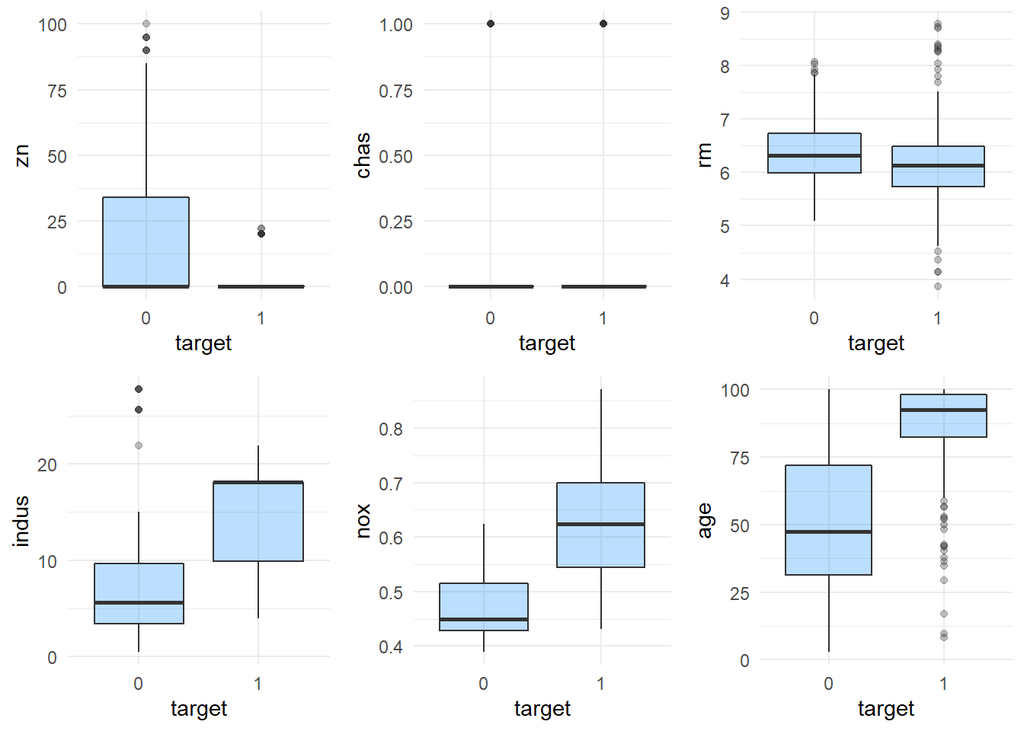

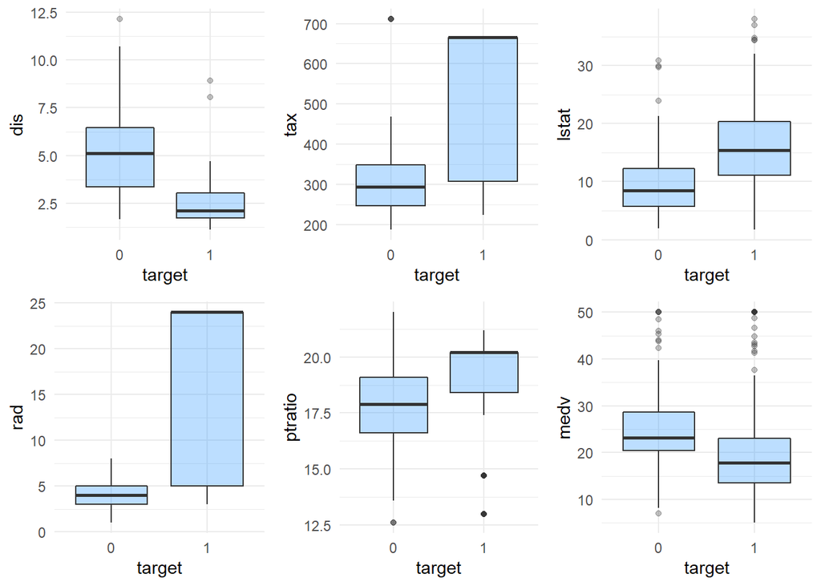

## Correlation

The following constructs a correlation matrix with heatmap. This matrix measures linear relationships between the variables. These values range from -1 to 1. If the value is close to -1, there is a strong negative correlation between the variables. If there is a value close to 1, there is a strong positive correlation between the variables.

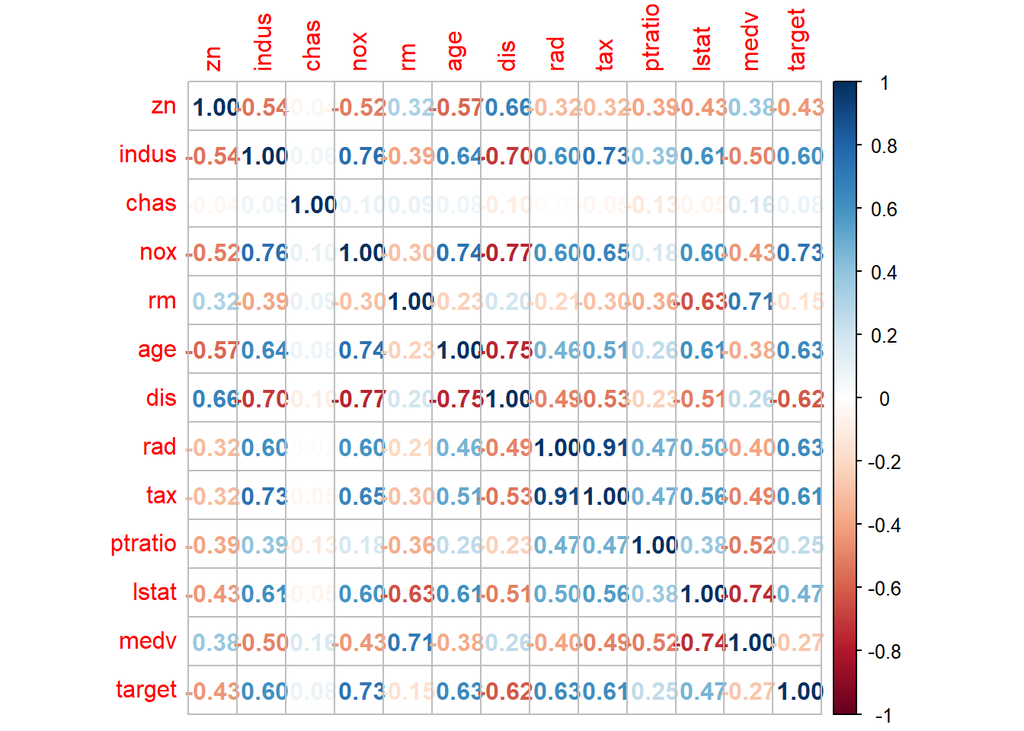

```
##               zn    indus     chas      nox       rm      age      dis     rad
## zn       1.00000 -0.53827 -0.04016 -0.51705  0.31981 -0.57258  0.66012 -0.3155
## indus   -0.53827  1.00000  0.06118  0.75963 -0.39271  0.63958 -0.70362  0.6006
## chas    -0.04016  0.06118  1.00000  0.09746  0.09051  0.07888 -0.09658 -0.0159
## nox     -0.51705  0.75963  0.09746  1.00000 -0.29549  0.73513 -0.76888  0.5958
## rm       0.31981 -0.39271  0.09051 -0.29549  1.00000 -0.23281  0.19902 -0.2084
## age     -0.57258  0.63958  0.07888  0.73513 -0.23281  1.00000 -0.75090  0.4603
## dis      0.66012 -0.70362 -0.09658 -0.76888  0.19902 -0.75090  1.00000 -0.4950
## rad     -0.31548  0.60063 -0.01590  0.59583 -0.20845  0.46031 -0.49499  1.0000
## tax     -0.31928  0.73223 -0.04676  0.65388 -0.29693  0.51212 -0.53425  0.9065
## ptratio -0.39104  0.39469 -0.12866  0.17627 -0.36035  0.25545 -0.23334  0.4715
## lstat   -0.43299  0.60711 -0.05142  0.59624 -0.63202  0.60562 -0.50753  0.5031
## medv     0.37672 -0.49617  0.16157 -0.43012  0.70534 -0.37816  0.25669 -0.3977
## target  -0.43168  0.60485  0.08004  0.72611 -0.15255  0.63011 -0.61867  0.6281
##              tax ptratio    lstat    medv   target
## zn      -0.31928 -0.3910 -0.43299  0.3767 -0.43168
## indus    0.73223  0.3947  0.60711 -0.4962  0.60485
## chas    -0.04676 -0.1287 -0.05142  0.1616  0.08004
## nox      0.65388  0.1763  0.59624 -0.4301  0.72611
## rm      -0.29693 -0.3603 -0.63202  0.7053 -0.15255
## age      0.51212  0.2554  0.60562 -0.3782  0.63011
## dis     -0.53425 -0.2333 -0.50753  0.2567 -0.61867
## rad      0.90646  0.4715  0.50310 -0.3977  0.62810
## tax      1.00000  0.4744  0.56419 -0.4900  0.61111
## ptratio  0.47442  1.0000  0.37736 -0.5159  0.25085
## lstat    0.56419  0.3774  1.00000 -0.7358  0.46913
## medv    -0.49003 -0.5159 -0.73580  1.0000 -0.27055
## target   0.61111  0.2508  0.46913 -0.2706  1.00000
```

# Data Preparation

The variable `zn` will undergo a log transformation.

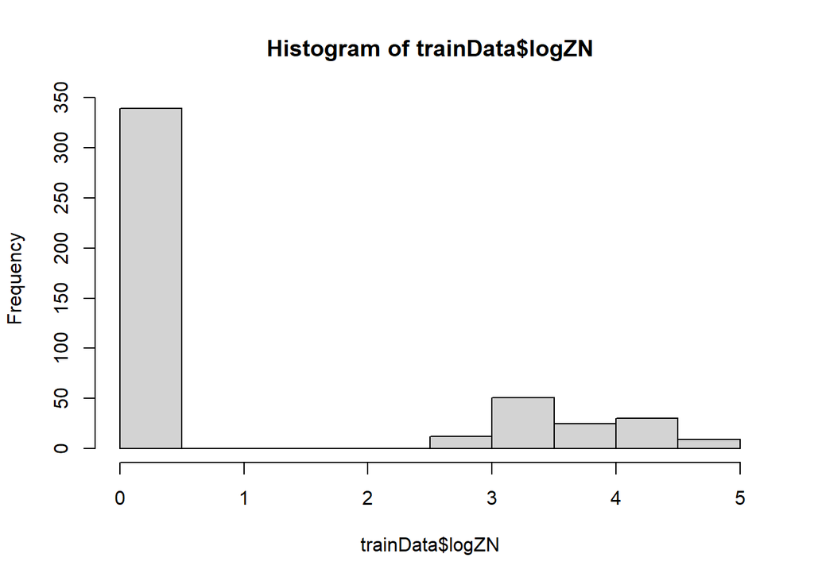

## Collinearity

The VIF (variance inflation factors): “Calculates variance-inflation and generalized variance-inflation factors (VIFs and GVIFs) for linear, generalized linear, and other regression models.” If the VIF = 1, then not correlated. If the VIF is in the range (1,5), it is moderately correlated. If the VID is greater than 5, the predictors are highly correlated. Overall, vif, helps to identify collinearity.

```
##   indus    chas     nox      rm     age     dis     rad     tax ptratio   lstat
##   4.118   1.091   4.508   2.360   3.105   4.321   6.694   8.765   2.142   3.644
##    medv   logZN
##   3.627   2.595
```

## Splitting

I split the training data into two partitions.

|  | zn | indus | chas | nox | rm | age | dis | rad | tax | ptratio | lstat | medv | target | logZN |
| --- | --- | --- | --- | --- | --- | --- | --- | --- | --- | --- | --- | --- | --- | --- |
| 1 | 0 | 19.58 | 0 | 0.605 | 7.929 | 96.2 | 2.046 | 5 | 403 | 14.7 | 3.70 | 50.0 | 1 | 0.000 |
| 2 | 0 | 19.58 | 1 | 0.871 | 5.403 | 100.0 | 1.322 | 5 | 403 | 14.7 | 26.82 | 13.4 | 1 | 0.000 |
| 3 | 0 | 18.10 | 0 | 0.740 | 6.485 | 100.0 | 1.978 | 24 | 666 | 20.2 | 18.85 | 15.4 | 1 | 0.000 |
| 4 | 30 | 4.93 | 0 | 0.428 | 6.393 | 7.8 | 7.035 | 6 | 300 | 16.6 | 5.19 | 23.7 | 0 | 3.434 |
| 6 | 0 | 8.56 | 0 | 0.520 | 6.781 | 71.3 | 2.856 | 5 | 384 | 20.9 | 7.67 | 26.5 | 0 | 0.000 |
| 8 | 0 | 18.10 | 0 | 0.693 | 4.519 | 100.0 | 1.658 | 24 | 666 | 20.2 | 36.98 | 7.0 | 1 | 0.000 |

|  | zn | indus | chas | nox | rm | age | dis | rad | tax | ptratio | lstat | medv | target | logZN |
| --- | --- | --- | --- | --- | --- | --- | --- | --- | --- | --- | --- | --- | --- | --- |
| 5 | 0 | 2.46 | 0 | 0.488 | 7.155 | 92.2 | 2.701 | 3 | 193 | 17.8 | 4.82 | 37.9 | 0 | 0.000 |
| 7 | 0 | 18.10 | 0 | 0.693 | 5.453 | 100.0 | 1.490 | 24 | 666 | 20.2 | 30.59 | 5.0 | 1 | 0.000 |
| 13 | 0 | 18.10 | 0 | 0.532 | 7.061 | 77.0 | 3.411 | 24 | 666 | 20.2 | 7.01 | 25.0 | 1 | 0.000 |
| 16 | 0 | 2.18 | 0 | 0.458 | 6.430 | 58.7 | 6.062 | 3 | 222 | 18.7 | 5.21 | 28.7 | 0 | 0.000 |
| 26 | 60 | 2.93 | 0 | 0.401 | 6.604 | 18.8 | 6.220 | 1 | 265 | 15.6 | 4.38 | 29.1 | 0 | 4.111 |
| 34 | 0 | 18.10 | 0 | 0.679 | 6.380 | 95.6 | 1.968 | 24 | 666 | 20.2 | 24.08 | 9.5 | 1 | 0.000 |

# Models

In developing the models, I used the `leaps` [package](https://cran.r-project.org/web/packages/leaps/leaps.pdf). According to the documentation, “leaps() performs an exhaustive search for the best subsets of the variables in x for predicting y in linear regression, using an efficient branch-and-bound algorithm.”

```
## $which
##        1     2    3     4     5     6     7     8     9     A     B     C
## 1  FALSE FALSE TRUE FALSE FALSE FALSE FALSE FALSE FALSE FALSE FALSE FALSE
## 2  FALSE FALSE TRUE FALSE FALSE FALSE  TRUE FALSE FALSE FALSE FALSE FALSE
## 3  FALSE FALSE TRUE FALSE  TRUE FALSE  TRUE FALSE FALSE FALSE FALSE FALSE
## 4  FALSE FALSE TRUE FALSE  TRUE FALSE  TRUE FALSE FALSE FALSE  TRUE FALSE
## 5  FALSE FALSE TRUE FALSE  TRUE FALSE  TRUE FALSE FALSE FALSE  TRUE  TRUE
## 6  FALSE FALSE TRUE FALSE  TRUE FALSE  TRUE FALSE FALSE  TRUE  TRUE  TRUE
## 7  FALSE FALSE TRUE FALSE  TRUE FALSE  TRUE  TRUE FALSE  TRUE  TRUE  TRUE
## 8  FALSE FALSE TRUE FALSE  TRUE  TRUE  TRUE  TRUE FALSE  TRUE  TRUE  TRUE
## 9  FALSE FALSE TRUE  TRUE  TRUE  TRUE  TRUE  TRUE FALSE  TRUE  TRUE  TRUE
## 10 FALSE  TRUE TRUE  TRUE  TRUE  TRUE  TRUE  TRUE FALSE  TRUE  TRUE  TRUE
## 11 FALSE  TRUE TRUE  TRUE  TRUE  TRUE  TRUE  TRUE  TRUE  TRUE  TRUE  TRUE
## 12  TRUE  TRUE TRUE  TRUE  TRUE  TRUE  TRUE  TRUE  TRUE  TRUE  TRUE  TRUE
##
## $label
##  [1] "(Intercept)" "1"           "2"           "3"           "4"
##  [6] "5"           "6"           "7"           "8"           "9"
## [11] "A"           "B"           "C"
##
## $size
##  [1]  2  3  4  5  6  7  8  9 10 11 12 13
##
## $Cp
##  [1] 103.631  42.313  20.230   8.248   6.323   5.878   5.432   6.640   8.063
## [10]   9.491  11.171  13.000
```

```
## [1] 5.432
```

The best variable selection using the lowest Mallow’s Cp value is #7 with Cp value of 5.4.

**7 FALSE FALSE TRUE FALSE TRUE FALSE TRUE TRUE FALSE TRUE TRUE TRUE**

```
##  [1] "indus"   "chas"    "nox"     "rm"      "age"     "dis"     "rad"
##  [8] "tax"     "ptratio" "lstat"   "medv"    "logZN"
```

| Variable | Present |
| --- | --- |
| indus | FALSE |
| chas | FALSE |
| nox | TRUE |
| rm | FALSE |
| age | TRUE |
| dis | FALSE |
| rad | TRUE |
| tax | TRUE |
| ptratio | FALSE |
| lstat | TRUE |
| medv | TRUE |
| logZN | TRUE |

The variables to use are `nox`, `age`, `rad`, `tax`, `lstat`, `medv`, and `logZN`.

# Build Models

## 1st Model

Using the information about the model with the lowest Mallow’s Cp value, I build a model using the seven variables. Here is a summary of the model:

```
##
## Call:
## glm(formula = target ~ nox + age + rad + tax + lstat + medv +
##     logZN, family = "binomial", data = training)
##
## Deviance Residuals:
##     Min       1Q   Median       3Q      Max
## -1.8293  -0.2311  -0.0099   0.0157   3.0566
##
## Coefficients:
##              Estimate Std. Error z value      Pr(>|z|)
## (Intercept) -18.70440    2.97969   -6.28 0.00000000034 ***
## nox          25.97971    5.33817    4.87 0.00000113429 ***
## age           0.02135    0.01143    1.87       0.06174 .
## rad           0.57868    0.15389    3.76       0.00017 ***
## tax          -0.00891    0.00302   -2.95       0.00321 **
## lstat         0.08458    0.04822    1.75       0.07945 .
## medv          0.08971    0.04273    2.10       0.03578 *
## logZN        -0.54269    0.22576   -2.40       0.01622 *
## ---
## Signif. codes:  0 '***' 0.001 '**' 0.01 '*' 0.05 '.' 0.1 ' ' 1
##
## (Dispersion parameter for binomial family taken to be 1)
##
##     Null deviance: 517.06  on 372  degrees of freedom
## Residual deviance: 166.16  on 365  degrees of freedom
## AIC: 182.2
##
## Number of Fisher Scoring iterations: 9
```

Now, let’s look at how the model works with our test data.

|  | actual | predictedProb | prediction |
| --- | --- | --- | --- |
| 5 | 0 | 0.441750 | 0 |
| 7 | 1 | 0.999996 | 1 |
| 13 | 1 | 0.999474 | 1 |
| 16 | 0 | 0.058449 | 0 |
| 26 | 0 | 0.000134 | 0 |
| 34 | 1 | 0.999993 | 1 |

```
## Confusion Matrix and Statistics
##
##           Reference
## Prediction  0  1
##          0 46  8
##          1  3 36
##
##                Accuracy : 0.882
##                  95% CI : (0.798, 0.939)
##     No Information Rate : 0.527
##     P-Value [Acc > NIR] : 0.000000000000287
##
##                   Kappa : 0.761
##
##  Mcnemar's Test P-Value : 0.228
##
##             Sensitivity : 0.818
##             Specificity : 0.939
##          Pos Pred Value : 0.923
##          Neg Pred Value : 0.852
##              Prevalence : 0.473
##          Detection Rate : 0.387
##    Detection Prevalence : 0.419
##       Balanced Accuracy : 0.878
##
##        'Positive' Class : 1
##
```

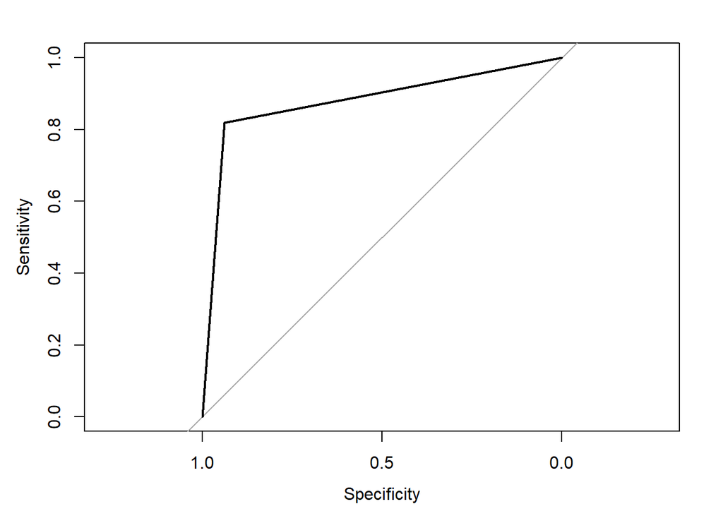

```
## Area under the curve: 0.878
```

## 2nd Model

```
##
## Call:
## glm(formula = target ~ indus + nox + rm + age + dis + rad + tax +
##     ptratio + lstat + medv + logZN, family = "binomial", data = training)
##
## Deviance Residuals:
##    Min      1Q  Median      3Q     Max
## -1.677  -0.173  -0.004   0.006   3.750
##
## Coefficients:
##              Estimate Std. Error z value   Pr(>|z|)
## (Intercept) -38.53472    7.76729   -4.96 0.00000070 ***
## indus        -0.07415    0.05148   -1.44     0.1498
## nox          46.11102    8.92269    5.17 0.00000024 ***
## rm           -0.20450    0.83187   -0.25     0.8058
## age           0.03768    0.01602    2.35     0.0187 *
## dis           0.77067    0.27107    2.84     0.0045 **
## rad           0.57259    0.17407    3.29     0.0010 **
## tax          -0.00693    0.00332   -2.09     0.0367 *
## ptratio       0.20132    0.13861    1.45     0.1464
## lstat         0.10883    0.06230    1.75     0.0807 .
## medv          0.20368    0.08091    2.52     0.0118 *
## logZN        -0.92228    0.33599   -2.74     0.0061 **
## ---
## Signif. codes:  0 '***' 0.001 '**' 0.01 '*' 0.05 '.' 0.1 ' ' 1
##
## (Dispersion parameter for binomial family taken to be 1)
##
##     Null deviance: 517.06  on 372  degrees of freedom
## Residual deviance: 152.88  on 361  degrees of freedom
## AIC: 176.9
##
## Number of Fisher Scoring iterations: 9
```

|  | actual | predictedProb | prediction |
| --- | --- | --- | --- |
| 5 | 0 | 0.52131793 | 1 |
| 7 | 1 | 0.99999852 | 1 |
| 13 | 1 | 0.99958632 | 1 |
| 16 | 0 | 0.16089247 | 0 |
| 26 | 0 | 0.00000898 | 0 |
| 34 | 1 | 0.99999773 | 1 |

```
## Confusion Matrix and Statistics
##
##           Reference
## Prediction  0  1
##          0 44  5
##          1  5 39
##
##                Accuracy : 0.892
##                  95% CI : (0.811, 0.947)
##     No Information Rate : 0.527
##     P-Value [Acc > NIR] : 0.0000000000000417
##
##                   Kappa : 0.784
##
##  Mcnemar's Test P-Value : 1
##
##             Sensitivity : 0.886
##             Specificity : 0.898
##          Pos Pred Value : 0.886
##          Neg Pred Value : 0.898
##              Prevalence : 0.473
##          Detection Rate : 0.419
##    Detection Prevalence : 0.473
##       Balanced Accuracy : 0.892
##
##        'Positive' Class : 1
##
```

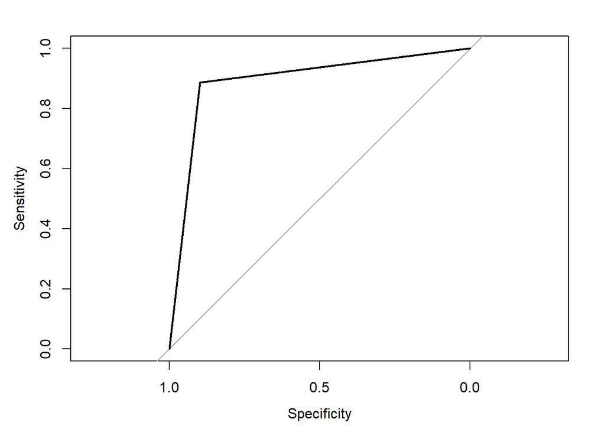

```
## Area under the curve: 0.892
```

## 3rd Model

[output not shown]

|  | actual | predictedProb | prediction |
| --- | --- | --- | --- |
| 5 | 0 | 0.255533 | 0 |
| 7 | 1 | 0.994339 | 1 |
| 13 | 1 | 0.519582 | 1 |
| 16 | 0 | 0.157210 | 0 |
| 26 | 0 | 0.001759 | 0 |
| 34 | 1 | 0.991505 | 1 |

```
## Confusion Matrix and Statistics
##
##           Reference
## Prediction  0  1
##          0 47  9
##          1  2 35
##
##                Accuracy : 0.882
##                  95% CI : (0.798, 0.939)
##     No Information Rate : 0.527
##     P-Value [Acc > NIR] : 0.000000000000287
##
##                   Kappa : 0.761
##
##  Mcnemar's Test P-Value : 0.0704
##
##             Sensitivity : 0.795
##             Specificity : 0.959
##          Pos Pred Value : 0.946
##          Neg Pred Value : 0.839
##              Prevalence : 0.473
##          Detection Rate : 0.376
##    Detection Prevalence : 0.398
##       Balanced Accuracy : 0.877
##
##        'Positive' Class : 1
##
```

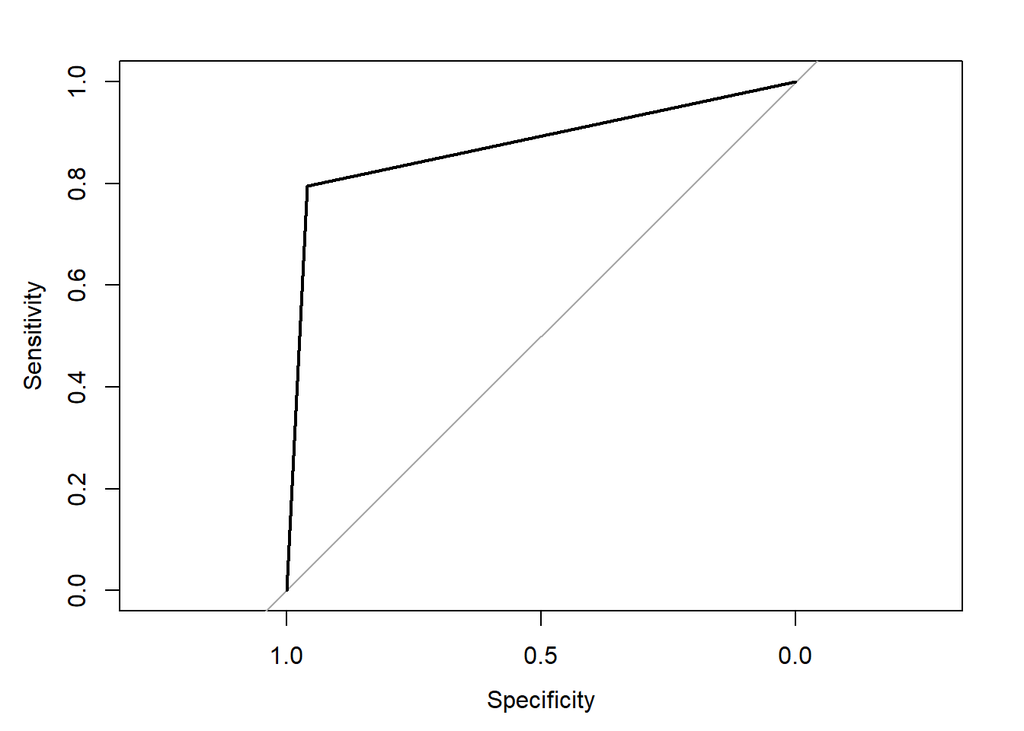

```
## Area under the curve: 0.877
```

# Model Selection

Surprisingly, I went with the 2nd model because it had a better accuracy than the others.

## Model and Evaluation Data

The model selected is applied to the evaluation data and stored in a column `prediction`.

|  | zn | indus | chas | nox | rm | age | dis | rad | tax | ptratio | lstat | medv | logZN | prediction |
| --- | --- | --- | --- | --- | --- | --- | --- | --- | --- | --- | --- | --- | --- | --- |
| 1 | 0 | 7.07 | 0 | 0.469 | 7.185 | 61.1 | 4.967 | 2 | 242 | 17.8 | 4.03 | 34.7 | 0.000 | 0 |
| 2 | 0 | 8.14 | 0 | 0.538 | 6.096 | 84.5 | 4.462 | 4 | 307 | 21.0 | 10.26 | 18.2 | 0.000 | 1 |
| 3 | 0 | 8.14 | 0 | 0.538 | 6.495 | 94.4 | 4.455 | 4 | 307 | 21.0 | 12.80 | 18.4 | 0.000 | 1 |
| 4 | 0 | 8.14 | 0 | 0.538 | 5.950 | 82.0 | 3.990 | 4 | 307 | 21.0 | 27.71 | 13.2 | 0.000 | 1 |
| 5 | 0 | 5.96 | 0 | 0.499 | 5.850 | 41.5 | 3.934 | 5 | 279 | 19.2 | 8.77 | 21.0 | 0.000 | 0 |
| 6 | 25 | 5.13 | 0 | 0.453 | 5.741 | 66.2 | 7.225 | 8 | 284 | 19.7 | 13.15 | 18.7 | 3.258 | 0 |